# threat classification

The dataset was created for the DARPA Intrusion Detection Evaluation Program, prepared and managed by MIT Lincoln Laboratory. The data was collected ovar nine weeks and consist of raw rcpdump traffic in a local area network (LAN) that simulates the environment of a typical US Air Forca LAN. Some network attacks were deliberetaly carried out during the recording period.

```python
import os
from collections  import defaultdict
import pandas as pd
import numpy as np
import matplotlib.pyplot as plt
import seaborn as sns
%matplotlib inline
```

```python
import warnings
warnings.filterwarnings('ignore')
sns.set()
```

```python
#the directory containing all of the relevant data files
dataset_root = '/home/mateusz/Documents/nsl-kdd/NSL-KDD-Dataset-9d544d0eb9b87d7e2f43ff65733bdb644631d12f/'
```

```python
train_file = os.path.join(dataset_root, 'KDDTrain+.txt')
test_file = os.path.join(dataset_root, 'KDDTest+.txt')
```

```python
#Original KDD dataset featur names obtained from
# http://kdd.ics.uci.edu/databases/kddcup99/kddcup.names
# http://kdd.ics.uci.edu/databases/kddcup99/kddcup99.html

header_names = ['duration', 'protocol_type', 'service', 'flag', 'src_bytes', 'dst_bytes', 'land', 'wrong_fragment', 'urgent', 'hot', 'num_failed_logins', 'logged_in', 'num_compromised', 'root_shell', 'su_attempted', 'num_root', 'num_file_creations', 'num_shells', 'num_access_files', 'num_outbound_cmds', 'is_host_login', 'is_guest_login', 'count', 'srv_count', 'serror_rate', 'srv_serror_rate', 'rerror_rate', 'srv_rerror_rate', 'same_srv_rate', 'diff_srv_rate', 'srv_diff_host_rate', 'dst_host_count', 'dst_host_srv_count', 'dst_host_same_srv_rate', 'dst_host_diff_srv_rate', 'dst_host_same_src_port_rate', 'dst_host_srv_diff_host_rate', 'dst_host_serror_rate', 'dst_host_srv_serror_rate', 'dst_host_rerror_rate', 'dst_host_srv_rerror_rate', 'attack_type', 'success_pred']
```

```python
#Differentiating between nominal, binary and numeric features

#root shell is marked as a continuous feature in the kddcup.names
#file, but ut us supposed to be a binary feature according to the data set documentation

col_names = np.array(header_names)

nominal_idx = [1,2,3]
binary_idx = [6, 11,13,14,20, 21]
numeric_idx = list(set(range(41)).difference(nominal_idx).difference(binary_idx))

nominal_cols = col_names[nominal_idx].tolist()
binary_cols = col_names[binary_idx].tolist()
numeric_cols = col_names[numeric_idx].tolist()
```

```python
#training_attack_types.txt maps each of the 22 different attacks to 1 of 4 catefories
#file obrained from http://kdd.ics.udi.edu/databases/kddcup99/training_attack_types
category = defaultdict(list)
category['benign'].append('normal')

with open(r'/home/mateusz/Documents/nsl-kdd/training_attack_types.txt', mode = 'r', encoding = 'utf-8-sig') as f:
    for line in f.readlines():
        print(line.strip().split(' '))
        attack, cat = line.strip().split(' ')
        category[cat].append(attack)

attack_mapping = dict((v,k) for k in category for v in category[k])
```

```
['back', 'dos']
['land', 'dos']
['neptune', 'dos']
['pod', 'dos']
['smurf', 'dos']
['teardrop', 'dos']
['apache2', 'dos']
['udpstorm', 'dos']
['processtable', 'dos']
['worm', 'dos']
['satan', 'probe']
['ipsweep', 'probe']
['nmap', 'probe']
['portsweep', 'probe']
['mscan', 'probe']
['saint', 'probe']
['guess_passwd', 'r2l']
['ftp_write', 'r2l']
['imap', 'r2l']
['phf', 'r2l']
['multihop', 'r2l']
['warezmaster', 'r2l']
['warezclient', 'r2l']
['spy', 'r2l']
['xlock', 'r2l']
['xsnoop', 'r2l']
['snmpguess', 'r2l']
['snmpgetattack', 'r2l']
['httptunnel', 'r2l']
['sendmail', 'r2l']
['named', 'r2l']
['buffer_overflow', 'u2r']
['loadmodule', 'u2r']
['rootkit', 'u2r']
['perl', 'u2r']
['sqlattack', 'u2r']
['xterm', 'u2r']
['ps', 'u2r']
['mailbomb', 'r2l']
```

```python
train_df = pd.read_csv(train_file, names=header_names)
train_df['attack_category'] = train_df['attack_type'] \
                                .map(lambda x: attack_mapping[x])
train_df.drop(['success_pred'], axis=1, inplace=True)

test_df = pd.read_csv(test_file, names=header_names)
test_df['attack_category'] = test_df['attack_type'] \
                                .map(lambda x: attack_mapping[x])
test_df.drop(['success_pred'], axis=1, inplace=True)
```

```python
train_attack_types = train_df['attack_type'].value_counts()
train_attack_cats = train_df['attack_category'].value_counts()
```

```python
test_attack_types = test_df['attack_type'].value_counts()
test_attack_cats = test_df['attack_category'].value_counts()
```

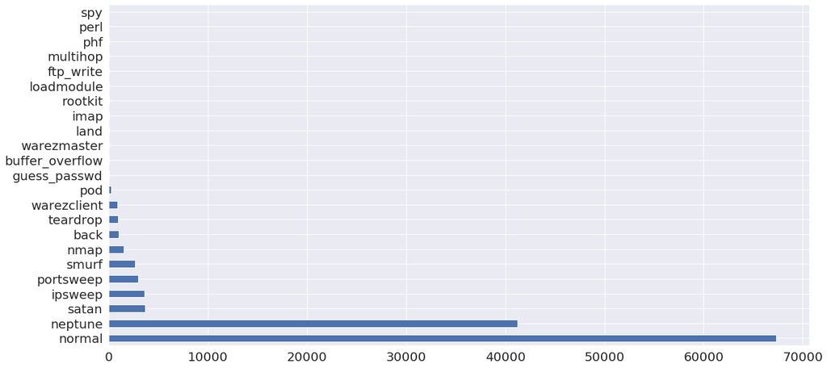

```python
train_attack_types.plot(kind='barh', figsize=(20,10), fontsize=20)
```

Above we can see the distribution of various types of attacks. Normal behavior and neptune far outnumber the rest of the types.

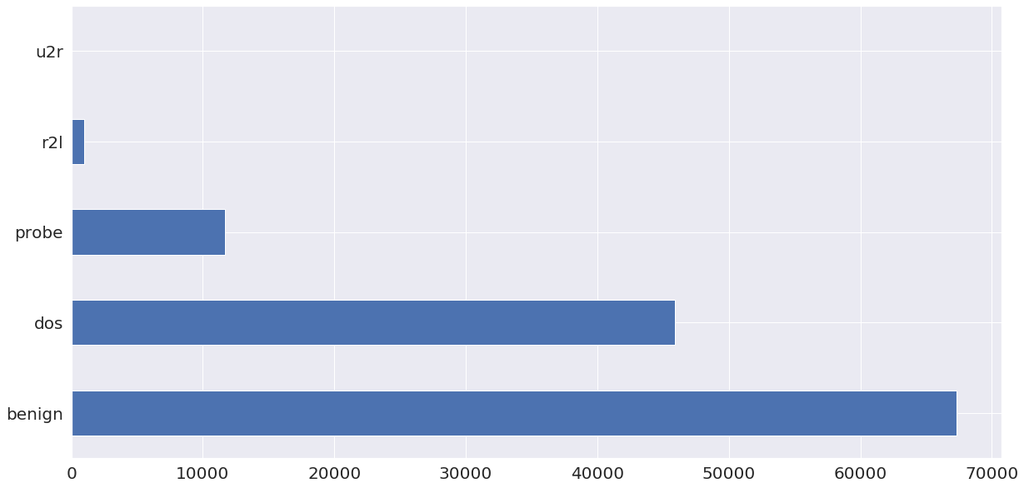

```python
train_attack_cats.plot(kind='barh', figsize=(20,10), fontsize = 20)
```

In the above plot it's seen that the number of benign behaviors is the biggest. Second most occured is denial of service.

It's worth noting that there are more types of vulnerabilities in test set than in a train set. We could potentially put the vulnerabilities with smaller number of occurences into a seperate category, say, other or just ignore them. it's a common practice to mitigate overfitting, avoid domination of one class.

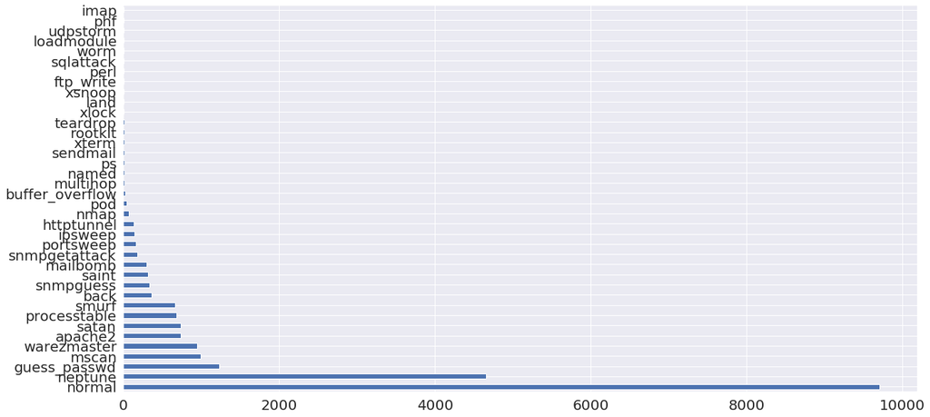

```python
test_attack_types.plot(kind='barh', figsize=(20,10), fontsize=20)
```

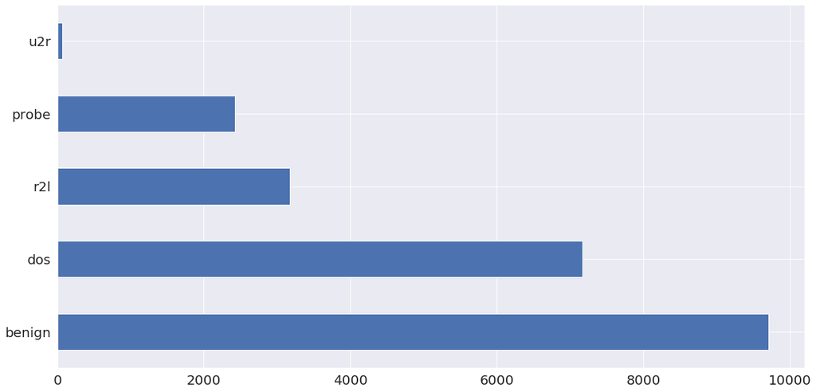

```python
test_attack_cats.plot(kind='barh', figsize=(20,10), fontsize = 20)
```

The data is tremendously imbalanced and it's necessary to balance out the data set in order to prevent the classifier from an undesireble bias by learning more about 'benign' and 'dos' classes, than 'u2r' and 'r2l' classes, since there are more occurences in the data of those.

The data was in structured and clean (no NULLs), with one exception where value 2 was assigned to one of the binary features 'su_attempted'.

```python
#Let's take a look at the binary features
#By definition, all of these features should have a min of 0.0 and max of 1.0

train_df[binary_cols].describe().transpose()
```

|  | count | mean | std | min | 25% | 50% | 75% | max |
| --- | --- | --- | --- | --- | --- | --- | --- | --- |
| land | 125973.0 | 0.000198 | 0.014086 | 0.0 | 0.0 | 0.0 | 0.0 | 1.0 |
| logged_in | 125973.0 | 0.395736 | 0.489010 | 0.0 | 0.0 | 0.0 | 1.0 | 1.0 |
| root_shell | 125973.0 | 0.001342 | 0.036603 | 0.0 | 0.0 | 0.0 | 0.0 | 1.0 |
| su_attempted | 125973.0 | 0.001103 | 0.045154 | 0.0 | 0.0 | 0.0 | 0.0 | 2.0 |
| is_host_login | 125973.0 | 0.000008 | 0.002817 | 0.0 | 0.0 | 0.0 | 0.0 | 1.0 |
| is_guest_login | 125973.0 | 0.009423 | 0.096612 | 0.0 | 0.0 | 0.0 | 0.0 | 1.0 |

```python
#su_attempted has a max value of 2.0
train_df.groupby(['su_attempted']).size()
```

```
su_attempted
0    125893
1        21
2        59
dtype: int64
```

```python
#fixing this discepancy and assuming that su_attempted=2 -> su_attempted=0

train_df['su_attempted'].replace(2, 0, inplace=True)
test_df['su_attempted'].replace(2, 0, inplace=True)
train_df.groupby(['su_attempted']).size()
```

```
su_attempted
0    125952
1        21
dtype: int64
```

```python
#it's not a useful feature - let's drop it from the dataset
train_df.drop('num_outbound_cmds', axis = 1, inplace=True)
test_df.drop('num_outbound_cmds', axis = 1, inplace=True)
numeric_cols.remove('num_outbound_cmds')
```

```python
#Data preparation
train_Y = train_df['attack_category']
train_x_raw = train_df.drop(['attack_category','attack_type'], axis=1)
test_Y = test_df['attack_category']
test_x_raw = test_df.drop(['attack_category','attack_type'], axis=1)
```

```python
combined_df_raw = pd.concat([train_x_raw, test_x_raw])
combined_df = pd.get_dummies(combined_df_raw, columns=nominal_cols, drop_first=True)

train_x = combined_df[:len(train_x_raw)]
test_x = combined_df[len(train_x_raw):]

#Store dummy variable feature names
dummy_variables = list(set(train_x) - set(combined_df_raw))
```

Let's getdescriptive statistics about our data to get some insight about it.

```python
train_x.describe()
```

[output not shown]

8 rows × 118 columns

```python
train_x['duration'].describe()
```

```
count    1.259730e+05
mean     3.916911e-16
std      1.000004e+00
min     -1.102492e-01
25%     -1.102492e-01
50%     -1.102492e-01
75%     -1.102492e-01
max      1.636428e+01
Name: duration, dtype: float64
```

```python
#Experimenting with StandardScaler on the single 'duration' feature
from sklearn.preprocessing import StandardScaler

durations = train_x['duration'].values.reshape(-1,1)
standard_scaler = StandardScaler().fit(durations)
scaled_durations = standard_scaler.transform(durations)
pd.Series(scaled_durations.flatten()).describe()
```

```
count    1.259730e+05
mean     3.907741e-16
std      1.000004e+00
min     -1.102492e-01
25%     -1.102492e-01
50%     -1.102492e-01
75%     -1.102492e-01
max      1.636428e+01
dtype: float64
```

```python
#Experimenting with MinMaxScaler on the single 'duration' feature
from sklearn.preprocessing import MinMaxScaler

min_max_scaler = MinMaxScaler().fit(durations)
min_max_scaled_durations = min_max_scaler.transform(durations)
pd.Series(min_max_scaled_durations.flatten()).describe()
```

```
count    125973.000000
mean          0.006692
std           0.060700
min           0.000000
25%           0.000000
50%           0.000000
75%           0.000000
max           1.000000
dtype: float64
```

```python
#Experimenting with RobustScaler on the single 'duration' feature
from sklearn.preprocessing import RobustScaler

min_max_scaler = RobustScaler().fit(durations)
robust_scaled_durations = min_max_scaler.transform(durations)
pd.Series(robust_scaled_durations.flatten()).describe()
```

```
count    125973.000000
mean          0.110249
std           1.000004
min           0.000000
25%           0.000000
50%           0.000000
75%           0.000000
max          16.474532
dtype: float64
```

```python
#Let's proceed with StandardScaler - Apply to all the numeric columns

standard_scaler = StandardScaler().fit(train_x[numeric_cols])

train_x[numeric_cols] = \
    standard_scaler.transform(train_x[numeric_cols])
test_x[numeric_cols] = \
    standard_scaler.transform(test_x[numeric_cols])
```

```python
train_x.describe()
```

|  | duration | src_bytes | dst_bytes | land | wrong_fragment | urgent | hot | num_failed_logins | logged_in | num_compromised | ... | flag_REJ | flag_RSTO | flag_RSTOS0 | flag_RSTR | flag_S0 | flag_S1 | flag_S2 | flag_S3 | flag_SF | flag_SH |
| --- | --- | --- | --- | --- | --- | --- | --- | --- | --- | --- | --- | --- | --- | --- | --- | --- | --- | --- | --- | --- | --- |
| count | 1.259730e+05 | 1.259730e+05 | 1.259730e+05 | 125973.000000 | 1.259730e+05 | 1.259730e+05 | 1.259730e+05 | 1.259730e+05 | 125973.000000 | 1.259730e+05 | ... | 125973.00000 | 125973.000000 | 125973.000000 | 125973.000000 | 125973.000000 | 125973.000000 | 125973.000000 | 125973.000000 | 125973.000000 | 125973.000000 |
| mean | 3.907741e-16 | 2.586483e-16 | -3.481835e-16 | 0.000198 | 1.031855e-15 | 3.111230e-15 | -7.604856e-15 | 8.220872e-16 | 0.395736 | -2.465977e-15 | ... | 0.08917 | 0.012399 | 0.000818 | 0.019218 | 0.276655 | 0.002897 | 0.001008 | 0.000389 | 0.594929 | 0.002151 |
| std | 1.000004e+00 | 1.000004e+00 | 1.000004e+00 | 0.014086 | 1.000004e+00 | 1.000004e+00 | 1.000004e+00 | 1.000004e+00 | 0.489010 | 1.000004e+00 | ... | 0.28499 | 0.110661 | 0.028583 | 0.137292 | 0.447346 | 0.053750 | 0.031736 | 0.019719 | 0.490908 | 0.046332 |
| min | -1.102492e-01 | -7.762241e-03 | -4.918644e-03 | 0.000000 | -8.948642e-02 | -7.735985e-03 | -9.507567e-02 | -2.702282e-02 | 0.000000 | -1.166364e-02 | ... | 0.00000 | 0.000000 | 0.000000 | 0.000000 | 0.000000 | 0.000000 | 0.000000 | 0.000000 | 0.000000 | 0.000000 |
| 25% | -1.102492e-01 | -7.762241e-03 | -4.918644e-03 | 0.000000 | -8.948642e-02 | -7.735985e-03 | -9.507567e-02 | -2.702282e-02 | 0.000000 | -1.166364e-02 | ... | 0.00000 | 0.000000 | 0.000000 | 0.000000 | 0.000000 | 0.000000 | 0.000000 | 0.000000 | 0.000000 | 0.000000 |
| 50% | -1.102492e-01 | -7.754745e-03 | -4.918644e-03 | 0.000000 | -8.948642e-02 | -7.735985e-03 | -9.507567e-02 | -2.702282e-02 | 0.000000 | -1.166364e-02 | ... | 0.00000 | 0.000000 | 0.000000 | 0.000000 | 0.000000 | 0.000000 | 0.000000 | 0.000000 | 1.000000 | 0.000000 |
| 75% | -1.102492e-01 | -7.715224e-03 | -4.790326e-03 | 0.000000 | -8.948642e-02 | -7.735985e-03 | -9.507567e-02 | -2.702282e-02 | 1.000000 | -1.166364e-02 | ... | 0.00000 | 0.000000 | 0.000000 | 0.000000 | 1.000000 | 0.000000 | 0.000000 | 0.000000 | 1.000000 | 0.000000 |
| max | 1.636428e+01 | 2.350675e+02 | 3.257486e+02 | 1.000000 | 1.174348e+01 | 2.088191e+02 | 3.571955e+01 | 1.104972e+02 | 1.000000 | 3.123689e+02 | ... | 1.00000 | 1.000000 | 1.000000 | 1.000000 | 1.000000 | 1.000000 | 1.000000 | 1.000000 | 1.000000 | 1.000000 |

8 rows × 118 columns

The distribution of rach feature vary widely, which will affect our results if we use any distance-based methods for classification. For instance, the mean of src_bytes is larger then the mean of num_failed_logins by seven orders of magnitude, and its standard deviation is larger by eigt orders of magnitude. Without performing feature value standardization/normalization, the src_bytes feature would dominate, causing the model to miss out on potentially important information in the num_failed_logins feature.

```python
train_Y_bin = train_Y.apply(lambda x: 0 if x is 'benign' else 1)
test_Y_bin = test_Y.apply(lambda x: 0 if x is 'benign' else 1)
```

```python
#5-class classification version
from sklearn.tree import DecisionTreeClassifier
from sklearn.metrics import confusion_matrix, zero_one_loss

classifier = DecisionTreeClassifier(random_state=17)
classifier.fit(train_x, train_Y)

pred_y = classifier.predict(test_x)

results = confusion_matrix(test_Y, pred_y)
error = zero_one_loss(test_Y, pred_y)

print(results)
print(error)
```

```
[[9365   56  289    1    0]
 [1072 5998   97    0    0]
 [ 675  220 1526    0    0]
 [2880    1   16  277    4]
 [  44    0    3    5   15]]
0.2378903477643719
```

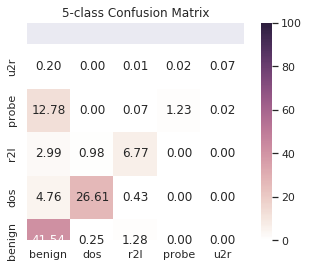

```python
sum = results.sum()

results = results * 100.0/(1.0 * sum)

df_cm = pd.DataFrame(results,
                  index = ['benign','dos','r2l','probe','u2r'],
                  columns= ['benign','dos','r2l','probe','u2r'])

fig = plt.figure()

plt.clf()

ax = fig.add_subplot(111)
ax.set_aspect(1)

cmap = sns.cubehelix_palette(light=1, as_cmap=True)

res = sns.heatmap(df_cm, annot= True, vmin=0.0, vmax=100.0, fmt='.2f', cmap=cmap)

res.invert_yaxis()

plt.yticks([0.5,1.5,2.5,3.5,4.5,5.5], ['benign','dos','r2l','probe','u2r'], va='center')

plt.title('5-class Confusion Matrix')
```

5-class Confusion Matrix shows us what proportion of points are classified correctly or misclassified by Decision Tree Clasifier. The number in the boxes is the percentage of all vulnerabilities. On diagonal we can see the vulnerabilities classified correctly, and that accounts for 76.22 % of all vulnerabilities and 23.78 % are misclassified.

Applying LinearSVC. 5-class confusion matrix shows the number of correctly and incorrectly classified datapoints. The error is larger than for Decision Tree Classifier.

```python
from sklearn.svm import LinearSVC

classifier = LinearSVC()
classifier.fit(train_x, train_Y)

pred_y = classifier.predict(test_x)

results = confusion_matrix(test_Y, pred_y)
error = zero_one_loss(test_Y, pred_y)

print(results)
print(error)
```

```
[[9008  292  407    3    1]
 [1503 5654   10    0    0]
 [ 714  122 1498   87    0]
 [3074    2    1  101    0]
 [  48    2    0    8    9]]
0.2783002129169624
```

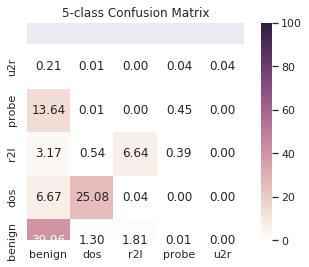

```python
sum = results.sum()

results = results * 100.0/(1.0 * sum)

df_cm = pd.DataFrame(results,
                  index = ['benign','dos','r2l','probe','u2r'],
                  columns= ['benign','dos','r2l','probe','u2r'])

fig = plt.figure()

plt.clf()

ax = fig.add_subplot(111)
ax.set_aspect(1)

cmap = sns.cubehelix_palette(light=1, as_cmap=True)

res = sns.heatmap(df_cm, annot= True, vmin=0.0, vmax=100.0, fmt='.2f', cmap=cmap)

res.invert_yaxis()

plt.yticks([0.5,1.5,2.5,3.5,4.5,5.5], ['benign','dos','r2l','probe','u2r'], va='center')

plt.title('5-class Confusion Matrix')
```

We can see below the distribution of all classes and it appears to be imbalanced.

```python
#Dealing with class imbalance
test_Y.value_counts().apply(lambda x: x/float(len(test_Y)))
```

```
benign    0.430758
dos       0.317912
r2l       0.140969
probe     0.107390
u2r       0.002972
Name: attack_category, dtype: float64
```

```python
train_Y.value_counts().apply(lambda x: x/float(len(train_Y))) #here as well
```

```
benign    0.534583
dos       0.364578
probe     0.092528
r2l       0.007899
u2r       0.000413
Name: attack_category, dtype: float64
```

```python
print(pd.Series(train_Y).value_counts())
#the number of occurences in each class
```

```
benign    67343
dos       45927
probe     11656
r2l         995
u2r          52
Name: attack_category, dtype: int64
```

Applying sampling techniques.

```python
from imblearn.over_sampling import SMOTE #oversampling

sm = SMOTE(ratio='auto', random_state=0)
train_x_sm, train_Y_sm = sm.fit_sample(train_x, train_Y)
print(pd.Series(train_Y_sm).value_counts())
```

```
r2l       67343
benign    67343
probe     67343
dos       67343
u2r       67343
dtype: int64
```

```python
from imblearn.under_sampling import RandomUnderSampler

mean_class_size = int(pd.Series(train_Y).value_counts().sum()/5)

ratio = {'benign': mean_class_size,
         'dos': mean_class_size,
         'probe': mean_class_size,
         'r2l': mean_class_size,
         'u2r': mean_class_size

}
rus =RandomUnderSampler(ratio=ratio, random_state=0, replacement=True)
train_x_rus, train_Y_rus = rus.fit_sample(train_x_sm, train_Y_sm)
print(pd.Series(train_Y_rus).value_counts())
```

```
probe     25194
r2l       25194
dos       25194
benign    25194
u2r       25194
dtype: int64
```

Having applied sampling techniques to balance out the class distribution, we feed the data to Decision Trees Classifier, as its performence was better than for linear model.

```python
from sklearn.tree import DecisionTreeClassifier
from sklearn.metrics import confusion_matrix, zero_one_loss

classifier = DecisionTreeClassifier(random_state=17)
classifier.fit(train_x_rus, train_Y_rus)

pred_y = classifier.predict(test_x)

results = confusion_matrix(test_Y, pred_y)
error = zero_one_loss(test_Y, pred_y)

print(results)
print(error)
```

```
[[9369   73  258    6    5]
 [ 752 5768  647    0    0]
 [ 268  170 1980    1    2]
 [2323    2  477  371    5]
 [  39    0    0   19    9]]
0.22387331440738112
```

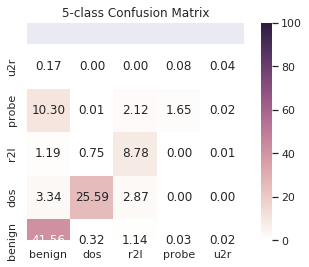

```python
sum = results.sum()

results = results * 100.0/(1.0 * sum)

df_cm = pd.DataFrame(results,
                  index = ['benign','dos','r2l','probe','u2r'],
                  columns= ['benign','dos','r2l','probe','u2r'])

fig = plt.figure()

plt.clf()

ax = fig.add_subplot(111)
ax.set_aspect(1)

cmap = sns.cubehelix_palette(light=1, as_cmap=True)

res = sns.heatmap(df_cm, annot= True, vmin=0.0, vmax=100.0, fmt='.2f', cmap=cmap)

res.invert_yaxis()

plt.yticks([0.5,1.5,2.5,3.5,4.5,5.5], ['benign','dos','r2l','probe','u2r'], va='center')

plt.title('5-class Confusion Matrix')
```

5-class Confusion Matrix shows us what proportion of classes are classified correctly or misclassified. The number in the boxes is the percentage of all vulnerabilities. On diagonal we can see the vulnerabilities classified correctly, and that accounts for 77.62 % of all vulnerabilities and 22.38 % are misclassified. Resampling helped us get from 76.2% accuracy to 77.6% It's not a huge improvement, but significant considering we haven't started doing any parameter tuning or extensive experimentation yet.

Attempting Unsupervised Learning

Clustering is a class of methods used in unsupervised learning. It's a technique that group similar data samples together, by definition of similarity. Each group of similar points is called a cluster and each cluster represents the learned model of a category. In our dataset we apply k-means clustering to find a pattern in unlabeled datapoints. We know that in our dataset contain five categories of samples, so we will choose the k-means clustering algorithm for the test with k = 5. K-means works only with continous data, hence we use only continious features in our data.

We applied PCA for dimensionality reduction in order to plot the relation between the vulnerabilities in 2D. We ignore labels and perform unsupervised learning to cluster datapoints by their similarities. The result is shown in the plot below.

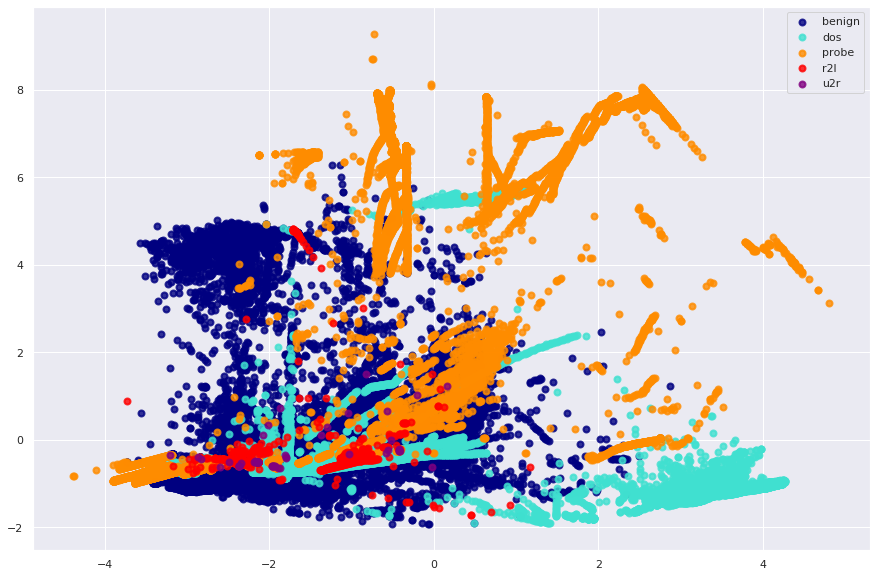

```python
# First, let's visualize the dataset (only numeric cols)

from sklearn.decomposition import PCA

# Use PCA to reduce dimensionality so we can visualize the dataset on a 2d plot
pca = PCA(n_components=2)
train_x_pca_cont = pca.fit_transform(train_x[numeric_cols])

plt.figure(figsize=(15,10))
colors = ['navy', 'turquoise', 'darkorange', 'red', 'purple']

for color, cat in zip(colors, category.keys()):
    plt.scatter(train_x_pca_cont[train_Y==cat, 0], train_x_pca_cont[train_Y==cat, 1],
                color=color, alpha=.8, lw=2, label=cat)
plt.legend(loc='best', shadow=False, scatterpoints=1)

plt.show()
```

The first principal component is represneted on the horizontal axis, and the second is represented on the vertical axis. It's seen that the dataset is not very suitable for clustering. The probe, dos and r2l sampples are scattered unpredictably, and do not form any strong clusters. Because there are few u2r samples, it is difficult to observe this class on the plot and it does not form any visible clusters. Only benign samples seem to form a strong cluster.

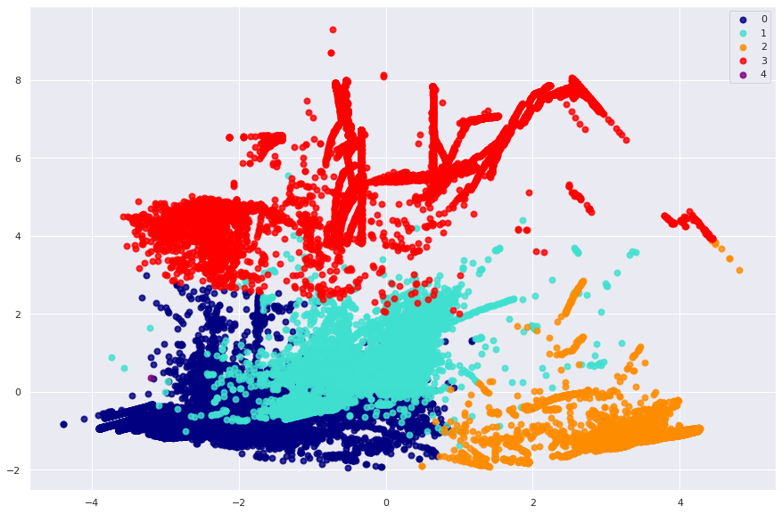

```python
# Apply k-means (k=5, only using numeric cols) + PCA + plot

from sklearn.cluster import KMeans

# Fit the training data to a k-means clustering estimator model
kmeans = KMeans(n_clusters=5, random_state=17).fit(train_x[numeric_cols])

# Retrieve the labels assigned to each training sample
kmeans_y = kmeans.labels_

# Plot in 2d with train_x_pca_cont
plt.figure(figsize=(15,10))
colors = ['navy', 'turquoise', 'darkorange', 'red', 'purple']

for color, cat in zip(colors, range(5)):
    plt.scatter(train_x_pca_cont[kmeans_y==cat, 0],
                train_x_pca_cont[kmeans_y==cat, 1],
                color=color, alpha=.8, lw=2, label=cat)
plt.legend(loc='best', shadow=False, scatterpoints=1)

plt.show()
```

It seems like the last cluster didn't get any membership of any of the test data points. We can observe significant differences in the clusters formed by k-means and the grond truth clusters. The algorithm performs well in grouping certain sections of the data together, but it fails to group clusters of the dos label and wrongly classifies a large section of "benign" trafic as attack traffic. None of the clusters have lables associated with them, thus evaluating results of clusters is not as simple as just comparing the predicted and expected labels. In the plot above, it's seen that there is a discrepancy between expected and predicted classes. The sense of how reliable the algorithm is, gives us metrics such as Completeness, Homogeneity and V-measure.

```python
print('Total number of features: {}'.format(len(train_x.columns)))
print('Total number of continuous features: {}'.format(len(train_x[numeric_cols].columns)))
```

```
Total number of features: 118
Total number of continuous features: 31
```

```python
from sklearn.metrics import completeness_score,\
    homogeneity_score, v_measure_score

print('Completeness: {}'.format(completeness_score(test_Y, pred_y)))
print('Homogeneity: {}'.format(homogeneity_score(test_Y, pred_y)))
print('V-measure: {}'.format(v_measure_score(test_Y, pred_y)))
```

```
Completeness: 0.5626714321250598
Homogeneity: 0.46266264944635305
V-measure: 0.507789724800292
```

A cluster is complete (has completeness score 1) if all data points belonging to the same class are clustered together. A cluster is homogoneous ( has homogeneity score 1) if all data points that are clustered together bolong tho the same class. The V-measure is a harmonic mean of homogeneity and completeness.

```python
#Using "Attribute Ratio" (AR) feature selection
averages = train_df.loc[:, numeric_cols].mean()
```

```python
averages_per_class = train_df[numeric_cols+['attack_category']].groupby('attack_category').mean()
```

```python
AR = {}
for col in numeric_cols:
    AR[col] = max(averages_per_class[col])/averages[col]
```

```python
AR #the score of AR corresponds to the feature's importance.
```

```
{'duration': 7.225829157212557,
 'src_bytes': 8.464064204948945,
 'dst_bytes': 9.154854355343401,
 'wrong_fragment': 2.742896335488928,
 'urgent': 173.03983516483518,
 'hot': 40.77451681709518,
 'num_failed_logins': 46.03855641845592,
 'num_compromised': 4.338539274983927,
 'num_root': 2.6091432537726016,
 'num_file_creations': 62.23362492770388,
 'num_shells': 326.11353550295854,
 'num_access_files': 4.694879248658319,
 'count': 2.1174082949142403,
 'srv_count': 1.1773191099992069,
 'serror_rate': 2.6310546426370025,
 'srv_serror_rate': 2.6432463184901405,
 'rerror_rate': 3.645586087828437,
 'srv_rerror_rate': 3.6677418023254122,
 'same_srv_rate': 1.507961200604778,
 'diff_srv_rate': 4.069085485068517,
 'srv_diff_host_rate': 3.0815657101101674,
 'dst_host_count': 1.3428596865228266,
 'dst_host_srv_count': 1.6453161847397422,
 'dst_host_same_srv_rate': 1.5575788279744123,
 'dst_host_diff_srv_rate': 4.837341848973267,
 'dst_host_same_src_port_rate': 4.3930803788834885,
 'dst_host_srv_diff_host_rate': 5.7568806827547,
 'dst_host_serror_rate': 2.6293396511769247,
 'dst_host_srv_serror_rate': 2.6731595957142456,
 'dst_host_rerror_rate': 3.2795669242442695,
 'dst_host_srv_rerror_rate': 3.667920527965804}
```

```python
def binary_AR(df, col):
    series_zero = train_df[train_df[col] == 0].groupby('attack_category').size()
    series_one = train_df[train_df[col] == 1].groupby('attack_category').size()
    return max(series_one/series_zero)
```

```python
# Recreating dataframes with 2-class and 5-class labels

labels2 = ['normal', 'attack']
labels5 = ['normal', 'dos', 'probe', 'r2l', 'u2r']

train_df = pd.read_csv(train_file, names=header_names)
train_df['attack_category'] = train_df['attack_type'] \
                                .map(lambda x: attack_mapping[x])
train_df.drop(['success_pred'], axis=1, inplace=True)

test_df = pd.read_csv(test_file, names=header_names)
test_df['attack_category'] = test_df['attack_type'] \
                                .map(lambda x: attack_mapping[x])
test_df.drop(['success_pred'], axis=1, inplace=True)

train_attack_types = train_df['attack_type'].value_counts()
train_attack_cats = train_df['attack_category'].value_counts()
test_attack_types = test_df['attack_type'].value_counts()
test_attack_cats = test_df['attack_category'].value_counts()
```

Although the data is clean, there is a small thing that need to be fixed. In the binary feature 'su_attempted' there is a value 2 that was probably entered by accident. Below we are replacing value of 2 by 0.

To simplify the problem, let's attempt to classify this network traffic into just the two classes: attack and benign.

```python
train_df['su_attempted'].replace(2, 0, inplace=True)
test_df['su_attempted'].replace(2, 0, inplace=True)
train_df.drop('num_outbound_cmds', axis = 1, inplace=True)
test_df.drop('num_outbound_cmds', axis = 1, inplace=True)
```

```python
train_df['labels2'] = train_df.apply(lambda x: 'normal' if 'normal' in x['attack_type'] else 'attack', axis=1)
test_df['labels2'] = test_df.apply(lambda x: 'normal' if 'normal' in x['attack_type'] else 'attack', axis=1)

combined_df = pd.concat([train_df, test_df])
original_cols = combined_df.columns

combined_df = pd.get_dummies(combined_df, columns=nominal_cols, drop_first=True)

added_cols = set(combined_df.columns) - set(original_cols)
added_cols= list(added_cols)
```

So far, we have been dealing with numerical values. Now, it's time to make use of categorical values.

```python
combined_df.attack_category = pd.Categorical(combined_df.attack_category)
combined_df.labels2 = pd.Categorical(combined_df.labels2)

combined_df['labels5'] = combined_df['attack_category'].cat.codes
combined_df['labels2'] = combined_df['labels2'].cat.codes
```

```python
train_df = combined_df[:len(train_df)]
test_df = combined_df[len(train_df):]
```

```python
for col in binary_cols+dummy_variables:
    cur_AR = binary_AR(train_df, col)
    if cur_AR:
        AR[col] = cur_AR
```

```python
train_df[train_df.service_Z39_50 == 1].groupby('attack_category').size()
```

```
attack_category
benign      0
dos       851
probe      11
r2l         0
u2r         0
dtype: int64
```

```python
len(binary_cols+added_cols)
```

```
87
```

```python
import operator
AR = dict((k, v) for k,v in AR.items() if not np.isnan(v))
sorted_AR = sorted(AR.items(), key=lambda x:x[1], reverse=True)
```

```python
sorted_AR
```

```
[('protocol_type_tcp', inf),
 ('num_shells', 326.11353550295854),
 ('urgent', 173.03983516483518),
 ('num_file_creations', 62.23362492770388),
 ('flag_SF', 51.0),
 ('num_failed_logins', 46.03855641845592),
 ('hot', 40.77451681709518),
 ('logged_in', 10.569767441860465),
 ('dst_bytes', 9.154854355343401),
 ('src_bytes', 8.464064204948945),
 ('duration', 7.225829157212557),
 ('dst_host_srv_diff_host_rate', 5.7568806827547),
 ('dst_host_diff_srv_rate', 4.837341848973267),
 ('num_access_files', 4.694879248658319),
 ('dst_host_same_src_port_rate', 4.3930803788834885),
 ('num_compromised', 4.338539274983927),
 ('diff_srv_rate', 4.069085485068517),
 ('dst_host_srv_rerror_rate', 3.667920527965804),
 ('srv_rerror_rate', 3.6677418023254122),
 ('rerror_rate', 3.645586087828437),
 ('dst_host_rerror_rate', 3.2795669242442695),
 ('srv_diff_host_rate', 3.0815657101101674),
 ('flag_S0', 2.965034965034965),
 ('wrong_fragment', 2.742896335488928),
 ('dst_host_srv_serror_rate', 2.6731595957142456),
 ('srv_serror_rate', 2.6432463184901405),
 ('serror_rate', 2.6310546426370025),
 ('dst_host_serror_rate', 2.6293396511769247),
 ('num_root', 2.6091432537726016),
 ('count', 2.1174082949142403),
 ('service_telnet', 1.8888888888888888),
 ('dst_host_srv_count', 1.6453161847397422),
 ('dst_host_same_srv_rate', 1.5575788279744123),
 ('service_ftp_data', 1.5447570332480818),
 ('same_srv_rate', 1.507961200604778),
 ('dst_host_count', 1.3428596865228266),
 ('service_http', 1.2988666621151088),
 ('srv_count', 1.1773191099992069),
 ('root_shell', 1.0),
 ('service_private', 0.7252812314979278),
```

[output cut: 63 more lines]

```
 ('service_printer', 0.0013517933064428214),
 ('service_shell', 0.0011553385359898854),
 ('su_attempted', 0.001006036217303823),
 ('service_X11', 0.0009958974968785302),
 ('service_pm_dump', 0.0004291477126426916),
 ('land', 0.00039207998431680063),
 ('service_aol', 0.00017161489617298782),
 ('service_http_8001', 0.00017161489617298782),
 ('service_harvest', 0.00017161489617298782),
 ('service_urh_i', 0.0001485155867108253),
 ('service_red_i', 0.00011880894037276305),
 ('service_http_2784', 8.58000858000858e-05),
 ('service_tim_i', 7.425227954498203e-05),
 ('service_tftp_u', 4.455004455004455e-05),
 ('is_host_login', 1.4849573817231445e-05)]
```

```python
# Only keep features with AR value >= 0.01

features_to_use = []
for x,y in sorted_AR:
    if y >= 0.01:
        features_to_use.append(x)

features_to_use
```

```
['protocol_type_tcp',
 'num_shells',
 'urgent',
 'num_file_creations',
 'flag_SF',
 'num_failed_logins',
 'hot',
 'logged_in',
 'dst_bytes',
 'src_bytes',
 'duration',
 'dst_host_srv_diff_host_rate',
 'dst_host_diff_srv_rate',
 'num_access_files',
 'dst_host_same_src_port_rate',
 'num_compromised',
 'diff_srv_rate',
 'dst_host_srv_rerror_rate',
 'srv_rerror_rate',
 'rerror_rate',
 'dst_host_rerror_rate',
 'srv_diff_host_rate',
 'flag_S0',
 'wrong_fragment',
 'dst_host_srv_serror_rate',
 'srv_serror_rate',
 'serror_rate',
 'dst_host_serror_rate',
 'num_root',
 'count',
 'service_telnet',
 'dst_host_srv_count',
 'dst_host_same_srv_rate',
 'service_ftp_data',
 'same_srv_rate',
 'dst_host_count',
 'service_http',
 'srv_count',
 'root_shell',
 'service_private',
```

[output cut: 21 more lines]

```
 'service_imap4',
 'service_nnsp',
 'service_vmnet',
 'service_time',
 'service_ctf',
 'service_csnet_ns',
 'service_supdup',
 'service_http_443',
 'service_discard',
 'service_domain',
 'service_daytime',
 'service_gopher',
 'service_efs',
 'service_exec',
 'service_systat']
```

```python
len(features_to_use)
```

```
76
```

```python
len(sorted_AR) - len(features_to_use)
```

```
42
```

We reduced the number of features to 76 the most informative ones.

```python
train_df_trimmed = train_df[features_to_use]
test_df_trimmed = test_df[features_to_use]
```

```python
numeric_cols_to_use = list(set(numeric_cols).intersection(features_to_use))
```

```python
# Rescaling is necessary after reducing dimensions

standard_scaler = StandardScaler()

train_df_trimmed[numeric_cols_to_use] = standard_scaler.fit_transform(train_df_trimmed[numeric_cols_to_use])
test_df_trimmed[numeric_cols_to_use] = standard_scaler.transform(test_df_trimmed[numeric_cols_to_use])
```

Applying advanced ensembling

```python
kmeans = KMeans(n_clusters=8, random_state=17)
kmeans.fit(train_df_trimmed[numeric_cols_to_use])
kmeans_train_y = kmeans.labels_
```

We select the most important features, apply PCA to reduce dimensions and k-means with 8 clusters and observe cross-tabulation of the eight k-means clusters and the ground truth binary labels

```python
pd.crosstab(kmeans_train_y, train_Y_bin)
```

| attack_category row_0 | 0 | 1 |
| --- | --- | --- |
| 0 | 63569 | 6457 |
| 1 | 2784 | 11443 |
| 2 | 126 | 34700 |
| 3 | 1 | 0 |
| 4 | 628 | 4335 |
| 5 | 167 | 757 |
| 6 | 0 | 884 |
| 7 | 68 | 54 |

Looking at the above table, we must consider how we want to deal with each cluster. Clusters 2 and 6 have a very clear majority of attack traffic, clusters 3 and 7 seem to contain only low level of noise, the rest of clusters are quite mixed.

Ensembling strategy

1. For clusters that have an aggregate size of fewer than 200 samples, we consider them outliers and assign them the attack label.
2. For clusters with more than 95% of samples belonging to a single class, (either attack or benign) we assign the dominant label to the entire cluster.
3. For each of the remaining clusters, we train a separate random forest classifier

   According to this strategy clusters 3 and 7 will be considered "noise" and be assigned the attack label. Clusters 2 and 6 both have more than 99% lf the traffic classified as attacks so that label propagates the entire class. We'll train decision tree classifiers for each of clusters 0,1, 4 and 5. We evaluate our method by first running the test samples through the k-means model to obtain the test clusters. Then, all the test samples assigned to cluster 2, 3, 6 and 7 will immediatly be labeled as attack. Test samples assigned to cluster 0 will be put through the decision tree classifiers train on cluster 0 from the training set, and so on.

```python
train_df['kmeans_y'] = kmeans_train_y
train_df_trimmed['kmeans_y'] = kmeans_train_y
```

```python
kmeans_test_y = kmeans.predict(test_df_trimmed[numeric_cols_to_use])
test_df['kmeans_y'] = kmeans_test_y
```

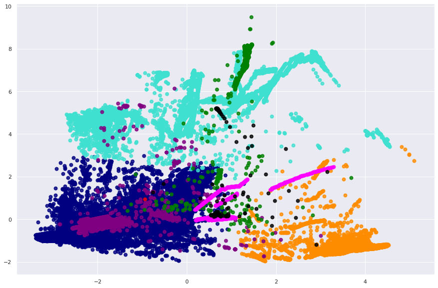

```python
pca8 = PCA(n_components=2)
train_df_trimmed_pca8 = pca8.fit_transform(train_df_trimmed)

plt.figure(figsize=(15,10))

colors8 = ['navy', 'turquoise', 'darkorange', 'red', 'purple', 'green', 'magenta', 'black']
labels8 = [0,1,2,3,4,5,6,7]

for color, cat in zip(colors8, labels8):
    plt.scatter(train_df_trimmed_pca8[train_df.kmeans_y==cat, 0], train_df_trimmed_pca8[train_df.kmeans_y==cat, 1],
                color=color, alpha=.8, lw=2, label=cat)
```

```python
pd.crosstab(test_df.kmeans_y, test_df.labels2)
```

| labels2 kmeans_y | 0 | 1 |
| --- | --- | --- |
| 0 | 4795 | 9515 |
| 1 | 5131 | 87 |
| 2 | 1997 | 6 |
| 4 | 427 | 51 |
| 5 | 1 | 10 |
| 6 | 8 | 37 |
| 7 | 474 | 5 |

Let's confirm the hypothesis by examining the confusion matrix.

```python
from sklearn.ensemble import RandomForestClassifier
from sklearn.metrics import accuracy_score
from sklearn.metrics import confusion_matrix
```

```python
#Cluster 0 - Random Forest Classifier
train_y0 = train_df[train_df.kmeans_y==0]
test_y0 = test_df[test_df.kmeans_y==0]
rfc = RandomForestClassifier(n_estimators=500, max_depth=20, random_state=17).fit(train_y0.drop(['labels2', 'labels5', 'kmeans_y', 'attack_category', 'attack_type'], axis=1), train_y0['labels2'])
pred_y0 = rfc.predict(test_y0.drop(['labels2', 'labels5', 'kmeans_y', 'attack_category', 'attack_type'], axis=1))
print("cluster {} score is {}, {}".format(0, accuracy_score(pred_y0, test_y0['labels2']), accuracy_score(pred_y0, test_y0['labels2'], normalize=False)))

print(confusion_matrix(test_y0['labels2'], pred_y0))
```

```
cluster 0 score is 0.7673654786862334, 10981
[[1618 3177]
 [ 152 9363]]
```

3177 out of 4795, that is 66% if the total false negative predictions made by the ensemble are caused by classifier 0's decision tree classifier. If we could make cluster 0's classifier better, we would greatly improve the ensemble classifier's overall perfomence.

```python
#Cluster 1 - Dominant Label Zero(Strategy Option 2)
print(confusion_matrix(test_df[test_df.kmeans_y==1]['labels2'], np.zeros(len(test_df[test_df.kmeans_y==1]))))
```

```
[[5131    0]
 [  87    0]]
```

```python
#Cluster 2 - Dominant Label Zero (stragegy option 2)
print(confusion_matrix(test_df[test_df.kmeans_y==2]['labels2'], np.zeros(len(test_df[test_df.kmeans_y==2]))))
```

```
[[1997    0]
 [   6    0]]
```

```python
#CLuster 3 - empty cluster
```

```python
#Cluster 4 - Random Forest Classifier
train_y0 = train_df[train_df.kmeans_y==4]
test_y0 = test_df[test_df.kmeans_y==4]
rfc = RandomForestClassifier(n_estimators=500, max_depth=20, random_state=17).fit(train_y0.drop(['labels2', 'labels5', 'kmeans_y', 'attack_category', 'attack_type'], axis=1), train_y0['labels2'])
pred_y0 = rfc.predict(test_y0.drop(['labels2', 'labels5', 'kmeans_y', 'attack_category', 'attack_type'], axis=1))
print("cluster {} score is {}, {}".format(4, accuracy_score(pred_y0, test_y0['labels2']), accuracy_score(pred_y0, test_y0['labels2'], normalize=False)))

print(confusion_matrix(test_y0['labels2'], pred_y0))
```

```
cluster 4 score is 0.9309623430962343, 445
[[405  22]
 [ 11  40]]
```

```python
#Cluster 5 - Outlier/Attack (stragegy option 1)
print(confusion_matrix(test_df[test_df.kmeans_y==5]['labels2'], np.ones(len(test_df[test_df.kmeans_y==5]))))
```

```
[[ 0  1]
 [ 0 10]]
```

```python
#Cluster 6 - Outlier/Attack (strategy option 1)
print(confusion_matrix(test_df[test_df.kmeans_y==6]['labels2'], np.ones(len(test_df[test_df.kmeans_y==6]))))
```

```
[[ 0  8]
 [ 0 37]]
```

```python
# Cluster 7 - dominant label zero (Strategy option 2)
print(confusion_matrix(test_df[test_df.kmeans_y==7]['labels2'], np.zeros(len(test_df[test_df.kmeans_y==7]))))
```

```
[[474   0]
 [  5   0]]
```

```python
#Combined Results: k-means + random forest classifier ensembling with AR feature selection


# combined results:
num_samples = 22544
false_pos = 3177 + 22 + 1 + 8
false_neg = 152 + 87 + 6 + 11 + 5

print('True positive %: {}'.format(1-(false_pos/num_samples)))
print('True negative %: {}'.format(1-(false_neg/num_samples)))
```

```
True positive %: 0.8577004968062456
True negative %: 0.9884226401703335
```

Combining the results we managed to classifiy attacks with accuracy 85.7% and benign with accuracy almost 99%.